# Two-day R course for Psychology

Andrew.Stewart@manchester.ac.uk

### Welcome!

January 31st and February 1st 2019

Turing Seminar Room, Coupland 1 Building

Morning Session 1000-1200 Afternoon Session 1330-1530

## Installing R and RStudio

You will probably want to bring a laptop for this course. Beforehand, you should install R (the language) and RStudio (the interface that helps us interact with R) - each is available for OSX, Windows, and various flavours of Unix. You can install R from here:

https://www.stats.bris.ac.uk/R/

And RStudio from here:

https://www.rstudio.com/products/rstudio/download/#download

## The Course Material

You can download the entire course content by clicking on the “Clone or download” buton on the GitHub page.

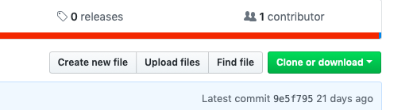

You will find folders for Day One and Day Two. Within each of these, you’ll find separate Morning and Afternoon folders. Each Morning folder contains the slides for the seminar, and the R code and data I use in the slides. The Afternoon folders contain the afternoon workshops (each written as an .html file - once downloaded these can be opened via your browser), and the data needed for each workshop. Additionally, you’ll also find a *Cheat Sheets and Handy Guides* folder which contains a number of helpful reference resources, and a Quick Start guide to begin working with R.

On Day One we will cover the basics of R, data wrangling, and data visualisation. On Day Two we will focus on the linear model (ANOVA and regression) and (generalised) linear mixed models (aka mixed models, hierarchical linear models, random effects models) for the modelling of normal, non-normal, and binomial data. Together, these two days will provide you with the skills needed to start working with R, the RStudio environment, and a variety of statistical models widely used in Psychology.

## Online R Resources

Below are some helpful R resources - it would be useful to look at the first one before the initial workshop.

##### Online introductory guide to R, RStudio, and R Markdown.

This is a very clear and focused introduction to R, RStudio, and R Markdown. You probably want to read the first four chapters sooner rather than later…

http://rbasics.netlify.com

##### R for Data Science online book - Garrett Grolemund and Hadley Wickham

This is the online interactive version of the book of the same name. It focuses more on the data science side of things than on statistics per se, and is very useful (especially in terms of data wrangling).

http://r4ds.had.co.nz

##### R Graphics Cookbook

The following *cookbook* contains lots of useful examples of graphing using the ggplot2 package in R.

http://www.cookbook-r.com/Graphs/

##### Mixed effects models in Ecology

You might like to read this great paper on mixed effects models in ecology before the second day of the workshop:

https://peerj.com/articles/4794/

If you have any questions in advance of the course, feel free to drop me an email (Andrew.Stewart@manchester.ac.uk)

Otherwise, I look forward to meeting you all on the 31st!